# JSC370 Midterm

Ella Hugie

2024-03-03

### 1. Introduction

The dataset I plan to use for my self-directed project contains information on Canadian Agency Advertising Gross Spending spanning from 2018 to 2023. Aggregated by Guideline and available via the Government of Canada Open Portal, this dataset offers a comprehensive view, encapsulating over 94% of the national agency spent within Canada’s media ecosystem. It provides various insights into agency advertising expenditure, delineating spending by product category, ad revenue allocation, and digital platforms. The dataset specifically includes variables such as Calendar Year, Quarter, Month, Province, Market, Media Type, Media Subtype, and Advertising Spend.

#### Question:

*Has the digitization of technology influenced the landscape of advertising in Canada, challenging traditional methods like radio and newspapers? Moreover, is digital advertising pervasive nationwide, occurring consistently, or is it specifically targeted to certain regions or times?*

### 2. Methods

The data for this analysis was acquired from the Government of Canada Open Portal, which makes comprehensive datasets pertaining to various aspects of Canadian governance and industry publicly available.

Link to Data: https://open.canada.ca/data/en/dataset/c4fef546-d355-4a12-b995-dd8257f55430

After loading in the data, it underwent a cleaning and wrangling process which involved checking for missing values, renaming variables, and creating new variables that will be used later in the analysis. Specifically, I modified the “Cal Quarter” variable to be numeric in nature as opposed to “Q1,” “Q2,” “Q3,” and “Q4” as well as added a Season variable (“Winter,” “Spring,” “Summer,” and “Fall”) since the Quarter variable corresponds to three month periods according to the fiscal calendar instead of seasons. Furthermore, both “Media_Type” and “Region” were factored since this will help facilitate categorical variable analysis.

Data exploration and analysis was conducted primarily using various statistical analysis and visualization packages in R including but not limited to dplyr, ggplot2, and tidyr. Both univarite and bivariate analysis was done by creating summary statistics for numerical variables, making frequency plots of categorical variables, faceting bar plots by other variables, and performing regressions.

**First Few Rows of the Dataset after Cleaning:**

| Year | Quarter | Month | Month_Numeric | Region | Market | Media_Type | Media_Sub_Type | Ad_Spending | Season |
| --- | --- | --- | --- | --- | --- | --- | --- | --- | --- |
| 2019 | 2 | June | 6 | National | National | Digital | Ad Network/Ad Exchange | 73668872 | Summer |
| 2022 | 4 | November | 11 | British Columbia | Vancouver - Victoria | Newspapers | Community Newspaper | 310804 | Fall |
| 2023 | 2 | May | 5 | Alberta | Lloydminster | Radio | Spot Radio | 219104 | Spring |
| 2022 | 1 | March | 3 | Ontario | Toronto - Hamilton - Niagara Falls | Radio | Other | 174581 | Spring |
| 2019 | 4 | December | 12 | Quebec | Chaleur Bay - Carleton | Linear Television | Specialty TV | 16601 | Winter |
| 2020 | 2 | June | 6 | Alberta | Medicine Hat | Linear Television | Spot TV | 18058 | Summer |

### 3. Preliminary Results

#### Variables and their types:

Summary of Advertising Dataset

|  | Class | Levels | Missing |
| --- | --- | --- | --- |
| Year | integer | 6 | 0 |
| Quarter | numeric | 4 | 0 |
| Month | character | 12 | 0 |
| Month_Numeric | integer | 12 | 0 |
| Region | factor | 15 | 0 |
| Market | character | 48 | 0 |
| Media_Type | factor | 7 | 0 |
| Media_Sub_Type | character | 30 | 0 |
| Ad_Spending | integer | 19912 | 0 |
| Season | character | 4 | 0 |

#### Key Numeric Variables:

Summary Statistics for Numeric Variables

|  | Min | Q1 | Median | Mean | Q3 | Max |
| --- | --- | --- | --- | --- | --- | --- |
| Year | 2018 | 2019.00 | 2020.0 | 2.020300e+03 | 2022.0 | 2023 |
| Quarter | 1 | 1.00 | 2.0 | 2.433814e+00 | 3.0 | 4 |
| Month_Numeric | 1 | 3.00 | 6.0 | 6.305388e+00 | 9.0 | 12 |
| Ad_Spending | -20182 | 7873.75 | 39748.5 | 1.439438e+06 | 194198.2 | 132756132 |

#### Key Categorical Variables:

[figure not shown]

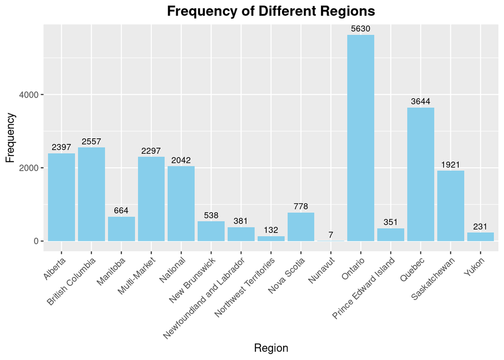

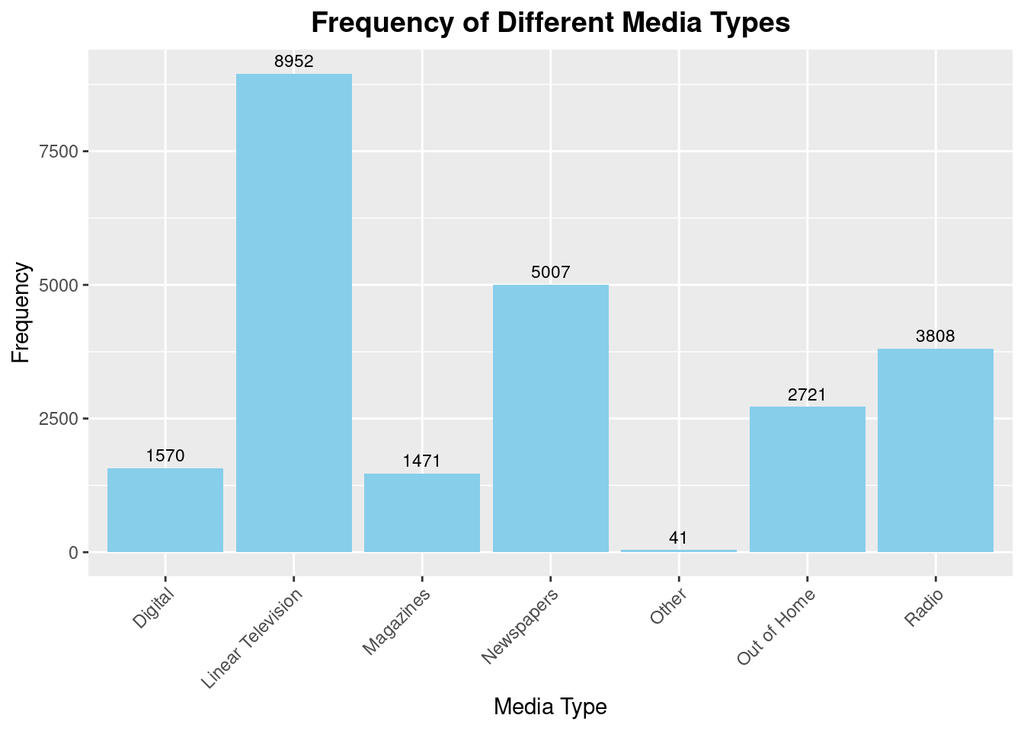

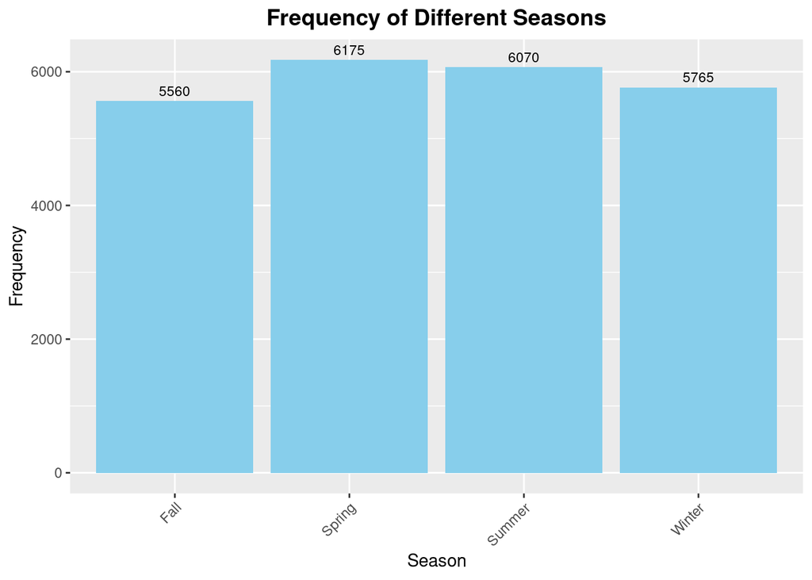

#### Trends in Digital, Radio, and Newspaper Advertising over Time:

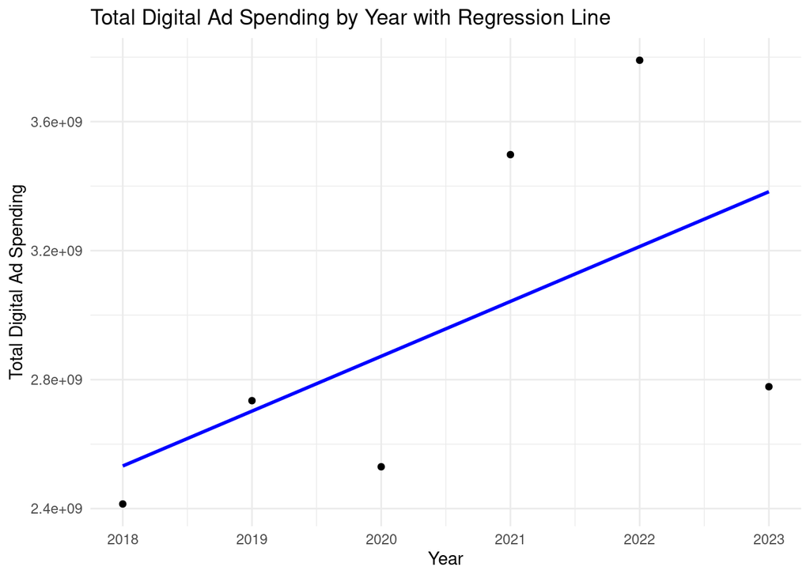

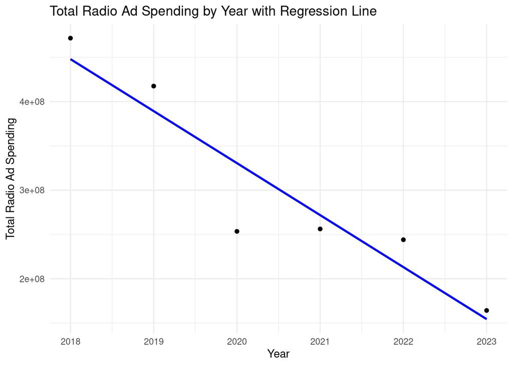

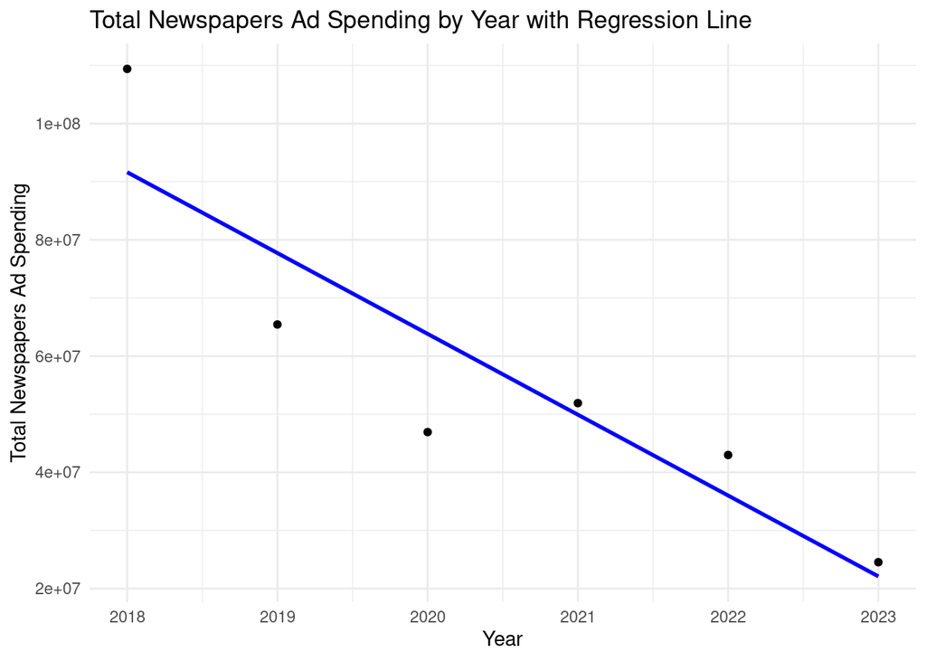

#### Advertising spent on Digital vs. Radio vs. Newspapers per Region:

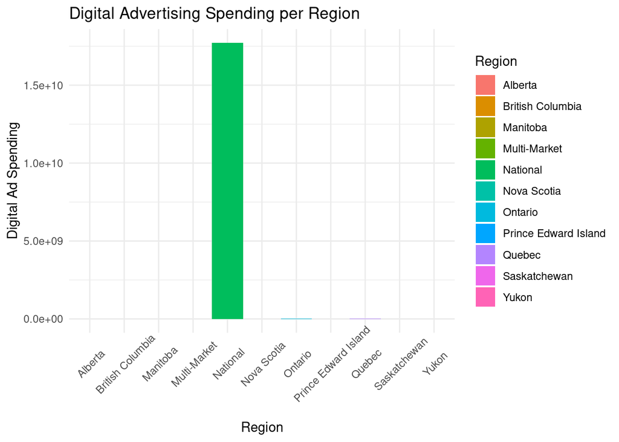

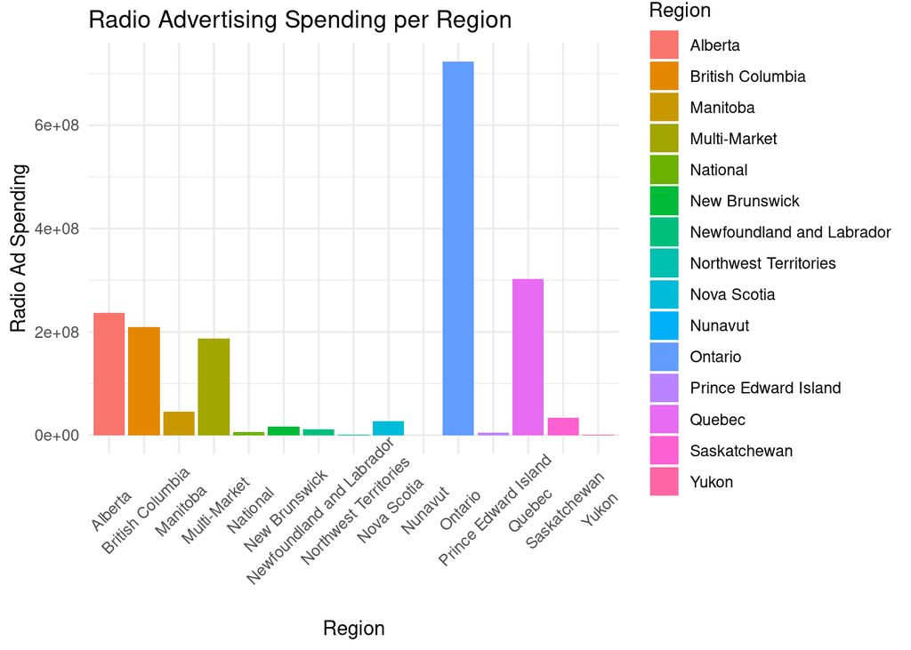

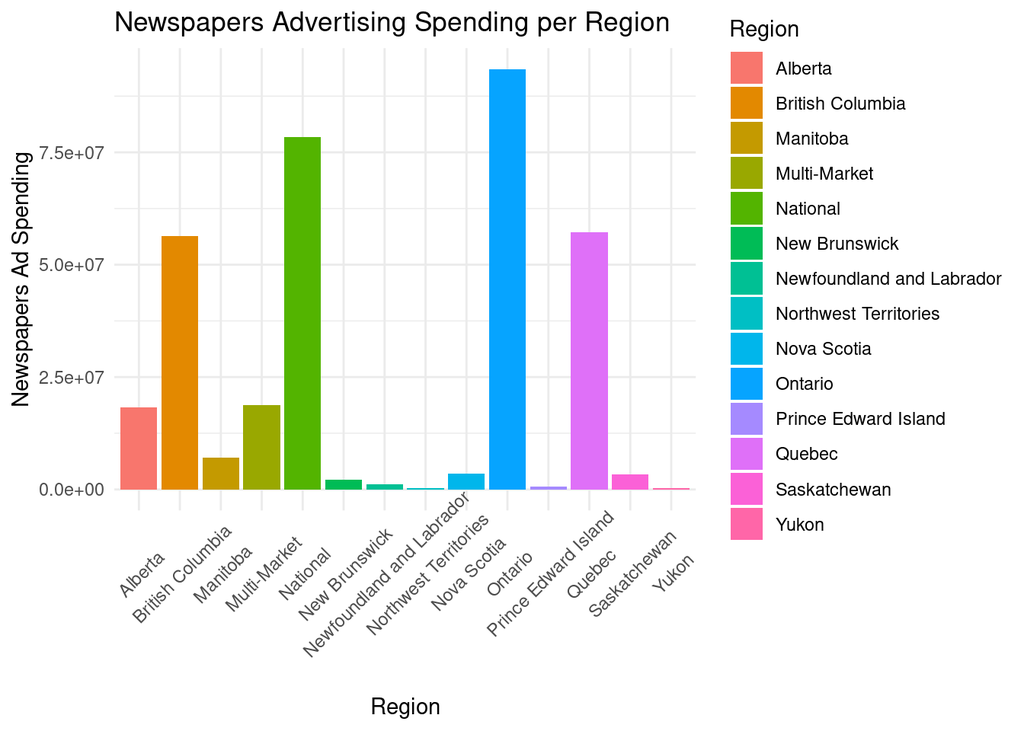